# CreditCardChurners

### Visualizing various continuous variables with Average Open To Buy coloured by Attrition Flag

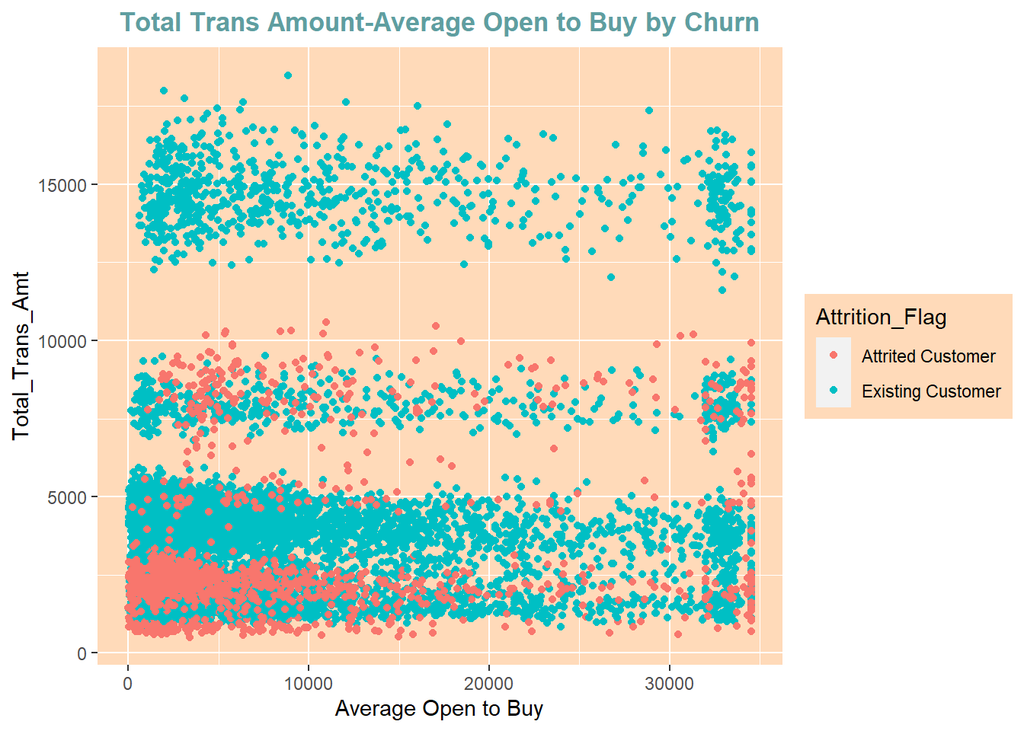

```r
ggplot(data = BankChurners,aes(y=Total_Trans_Amt,x=Avg_Open_To_Buy,col=Attrition_Flag))+geom_point()+labs(title = "Total Trans Amount-Average Open to Buy by Churn",x="Average Open to Buy",fill="Attrition Flag")+theme(panel.background = element_rect(fill = "peachpuff"))+theme(plot.title = element_text(hjust = 0.5,face = "bold",colour = "cadetblue"))+theme(legend.background = element_rect(fill = "peachpuff"))
```

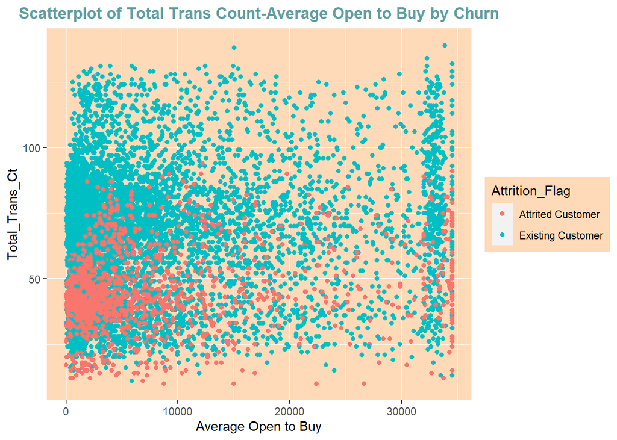

```r
ggplot(data = BankChurners,aes(y=Total_Trans_Ct,x=Avg_Open_To_Buy,col=Attrition_Flag))+geom_point()+labs(title = "Scatterplot of Total Trans Count-Average Open to Buy by Churn",x="Average Open to Buy",fill="Attrition Flag")+theme(panel.background = element_rect(fill = "peachpuff"))+theme(plot.title = element_text(hjust = 0.5,face = "bold",colour = "cadetblue"))+theme(legend.background = element_rect(fill = "peachpuff"))
```

1.From the graph above we see that the area of the customers with less than 20000 Average Open to Buy and Total Transfer Amount of less than 3000 have higher attrition rate followed by the area of the batch of the customers with Average Open to buy of less than 7000 and total transfer amount between 7500-1000. The customers with the total transfer amount of more than 12500 have no attrition at all as we have seen earlier also.

2. From the second graph above we see that the area between the average open to buy of less than 100000 and the Total transaction count of less than 50 contains attrited customers. Alsoo the customers with average open to buy of 34000 and total transaction count of less than 75 have the high attrition.

### Visualizing Total Transfer Count - Total Transfer Amount by Attrition Flag

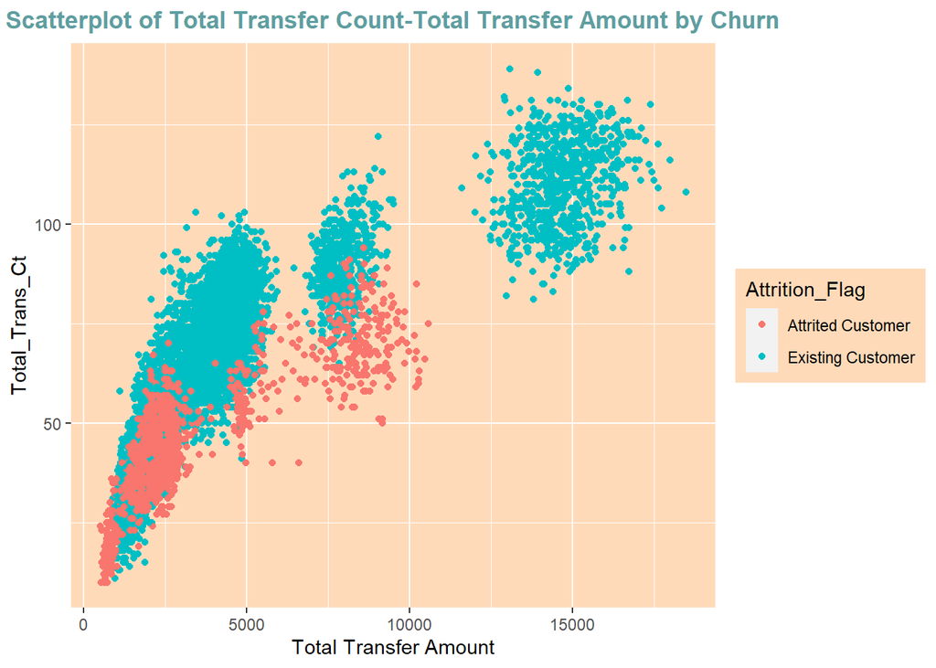

```r
ggplot(data = BankChurners,aes(y=Total_Trans_Ct,x=Total_Trans_Amt,col=Attrition_Flag))+geom_point()+labs(title = "Scatterplot of Total Transfer Count-Total Transfer Amount by Churn",x="Total Transfer Amount",fill="Attrition Flag")+theme(panel.background = element_rect(fill = "peachpuff"))+theme(plot.title = element_text(hjust = 0.5,face = "bold",colour = "cadetblue"))+theme(legend.background = element_rect(fill = "peachpuff"))
```

1. From the above graph we see that there are 3 chunks.In the first one we see that the customers with less than 4000 Total Transfer Amount and Total Trannsfer COunt of less than 70 have the high attrition rate. Also we see high attrition near the Total Transfer Amount of 5000 and Total Transaction Count between 35-75. In the second chunk we see that the customers with Total Transfer Amount of 7500-10000 and Total Transaction Count of 50-80 have high attrition rate. While in the third chunk attritioon rate is nill.

### Visualizing various categorical variables with Total Revolving Balance coloured by Attrition Flag

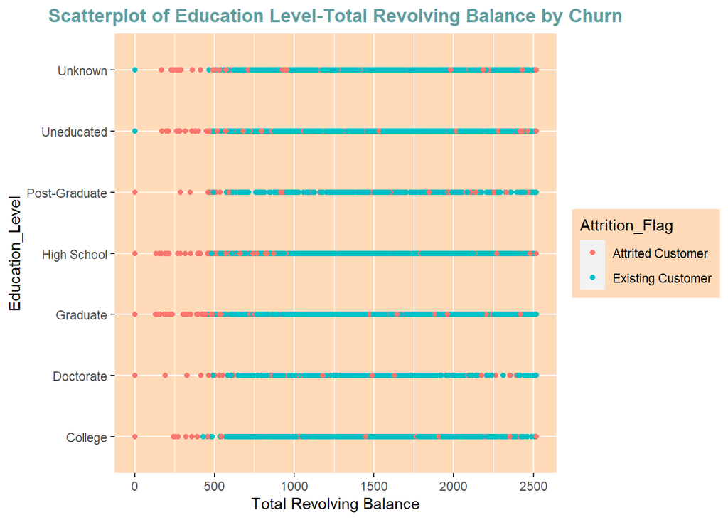

```r
ggplot(data = BankChurners,aes(y=Education_Level,x=Total_Revolving_Bal,col=Attrition_Flag))+geom_point()+labs(title = "Scatterplot of Education Level-Total Revolving Balance by Churn",x="Total Revolving Balance",fill="Attrition Flag")+theme(panel.background = element_rect(fill = "peachpuff"))+theme(plot.title = element_text(hjust = 0.5,face = "bold",colour = "cadetblue"))+theme(legend.background = element_rect(fill = "peachpuff"))
```

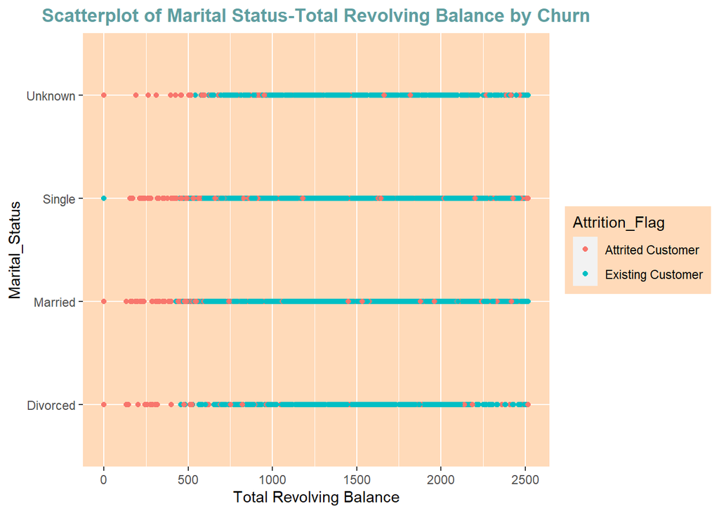

```r
ggplot(data = BankChurners,aes(y=Marital_Status,x=Total_Revolving_Bal,col=Attrition_Flag))+geom_point()+labs(title = "Scatterplot of Marital Status-Total Revolving Balance by Churn",x="Total Revolving Balance",fill="Attrition Flag")+theme(panel.background = element_rect(fill = "peachpuff"))+theme(plot.title = element_text(hjust = 0.5,face = "bold",colour = "cadetblue"))+theme(legend.background = element_rect(fill = "peachpuff"))
```

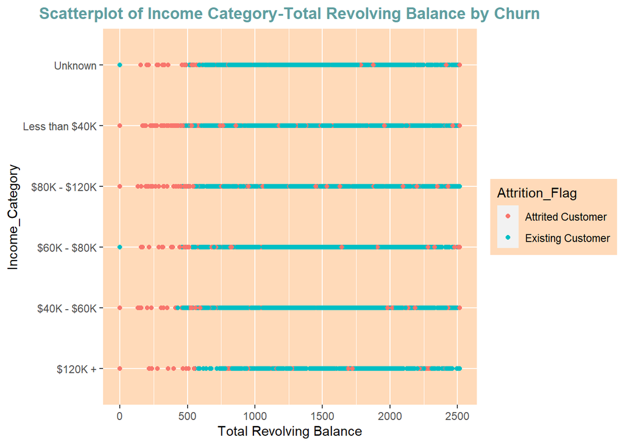

```r
ggplot(data = BankChurners,aes(y=Income_Category,x=Total_Revolving_Bal,col=Attrition_Flag))+geom_point()+labs(title = "Scatterplot of Income Category-Total Revolving Balance by Churn",x="Total Revolving Balance",fill="Attrition Flag")+theme(panel.background = element_rect(fill = "peachpuff"))+theme(plot.title = element_text(hjust = 0.5,face = "bold",colour = "cadetblue"))+theme(legend.background = element_rect(fill = "peachpuff"))
```

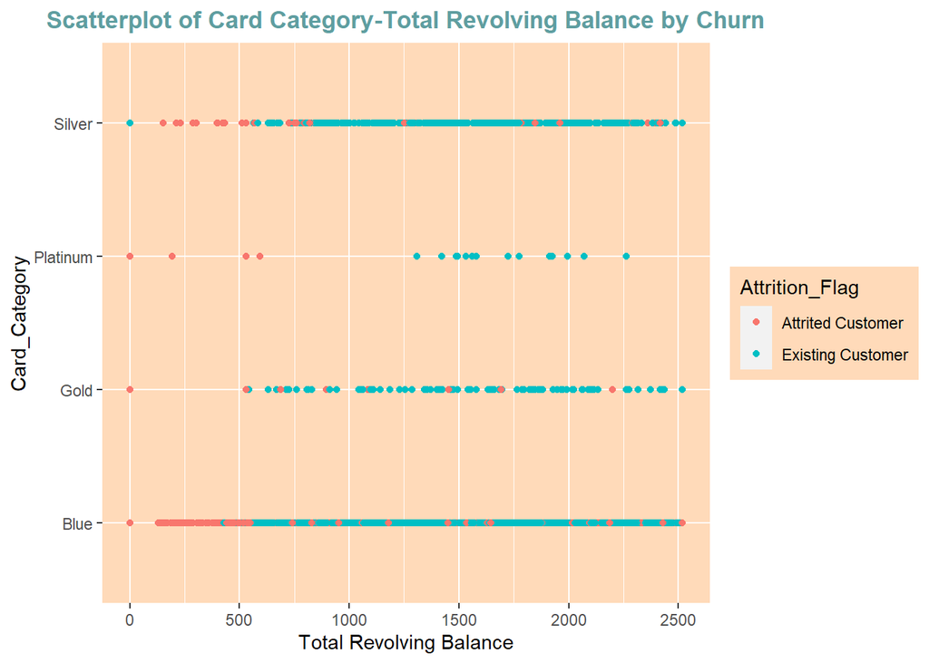

```r
ggplot(data = BankChurners,aes(y=Card_Category,x=Total_Revolving_Bal,col=Attrition_Flag))+geom_point()+labs(title = "Scatterplot of Card Category-Total Revolving Balance by Churn",x="Total Revolving Balance",fill="Attrition Flag")+theme(panel.background = element_rect(fill = "peachpuff"))+theme(plot.title = element_text(hjust = 0.5,face = "bold",colour = "cadetblue"))+theme(legend.background = element_rect(fill = "peachpuff"))
```

1. As is clear from the earlier observation, that the total revolving balance of less than 500 shows a higher attrition rate, in all the above four figures we observe that the total revolving Balance of less than 500 has a higher rate of attrition irrespective of any of the mentioned categotry.

### Visualizing various categorical variables with Total Transfer Amount coloured by Attrition Flag

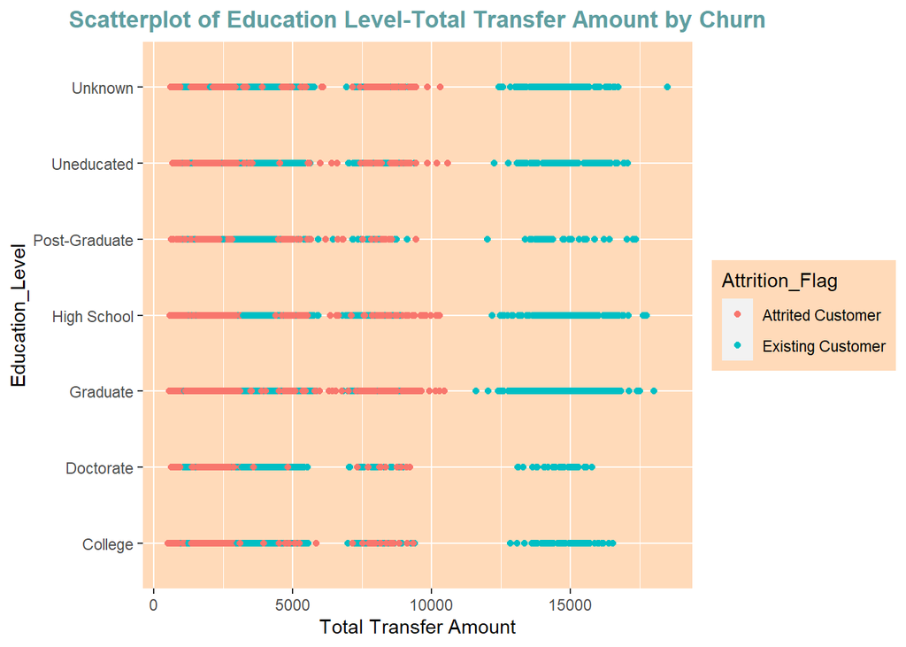

```r
ggplot(data = BankChurners,aes(y=Education_Level,x=Total_Trans_Amt,col=Attrition_Flag))+geom_point()+labs(title = "Scatterplot of Education Level-Total Transfer Amount by Churn",x="Total Transfer Amount",fill="Attrition Flag")+theme(panel.background = element_rect(fill = "peachpuff"))+theme(plot.title = element_text(hjust = 0.5,face = "bold",colour = "cadetblue"))+theme(legend.background = element_rect(fill = "peachpuff"))
```

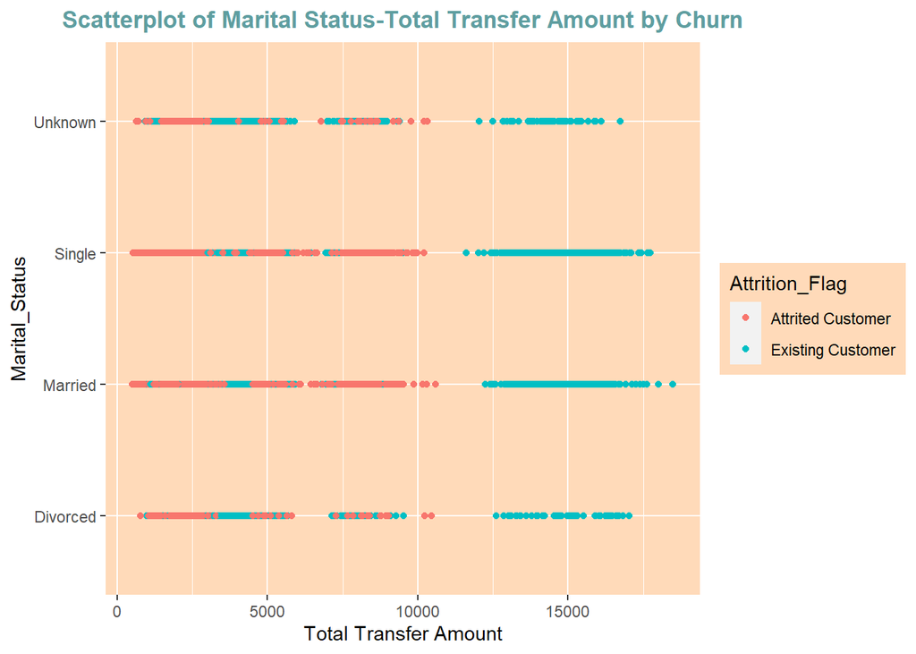

```r
ggplot(data = BankChurners,aes(y=Marital_Status,x=Total_Trans_Amt,col=Attrition_Flag))+geom_point()+labs(title = "Scatterplot of Marital Status-Total Transfer Amount by Churn",x="Total Transfer Amount",fill="Attrition Flag")+theme(panel.background = element_rect(fill = "peachpuff"))+theme(plot.title = element_text(hjust = 0.5,face = "bold",colour = "cadetblue"))+theme(legend.background = element_rect(fill = "peachpuff"))
```

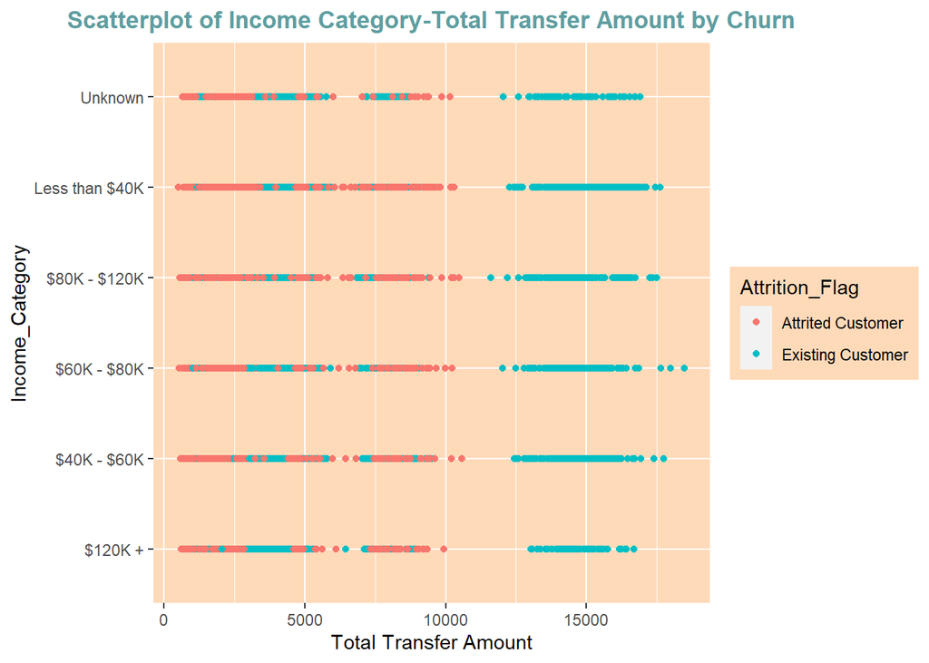

```r
ggplot(data = BankChurners,aes(y=Income_Category,x=Total_Trans_Amt,col=Attrition_Flag))+geom_point()+labs(title = "Scatterplot of Income Category-Total Transfer Amount by Churn",x="Total Transfer Amount",fill="Attrition Flag")+theme(panel.background = element_rect(fill = "peachpuff"))+theme(plot.title = element_text(hjust = 0.5,face = "bold",colour = "cadetblue"))+theme(legend.background = element_rect(fill = "peachpuff"))
```

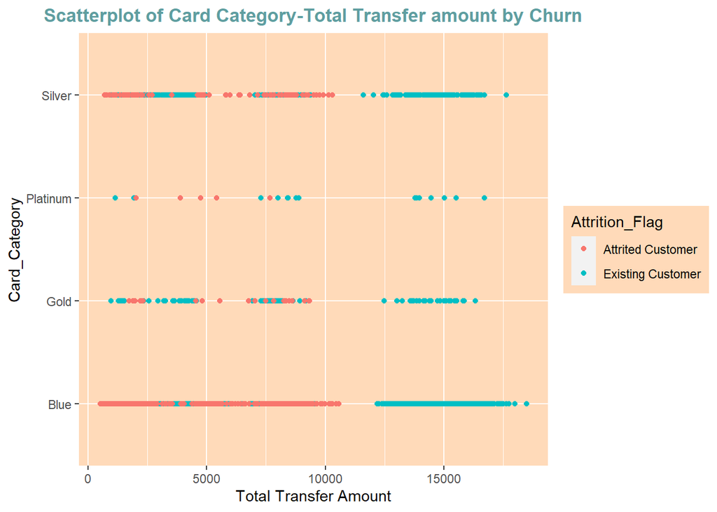

```r
ggplot(data = BankChurners,aes(y=Card_Category,x=Total_Trans_Amt,col=Attrition_Flag))+geom_point()+labs(title = "Scatterplot of Card Category-Total Transfer amount by Churn",x="Total Transfer Amount",fill="Attrition Flag")+theme(panel.background = element_rect(fill = "peachpuff"))+theme(plot.title = element_text(hjust = 0.5,face = "bold",colour = "cadetblue"))+theme(legend.background = element_rect(fill = "peachpuff"))
```

### Visualizing various categorical variables with Total Transfer Count coloured by Attrition Flag

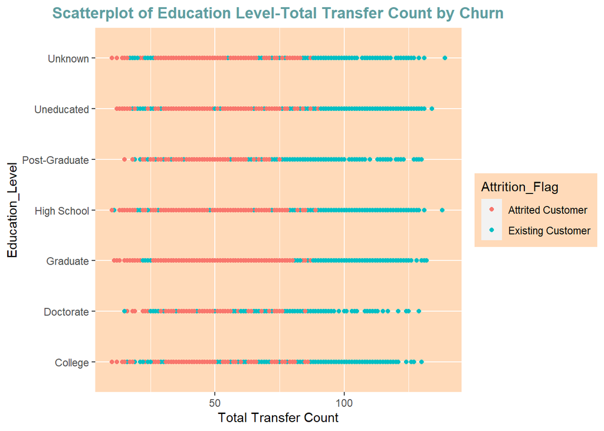

```r
ggplot(data = BankChurners,aes(y=Education_Level,x=Total_Trans_Ct,col=Attrition_Flag))+geom_point()+labs(title = "Scatterplot of Education Level-Total Transfer Count by Churn",x="Total Transfer Count",fill="Attrition Flag")+theme(panel.background = element_rect(fill = "peachpuff"))+theme(plot.title = element_text(hjust = 0.5,face = "bold",colour = "cadetblue"))+theme(legend.background = element_rect(fill = "peachpuff"))
```

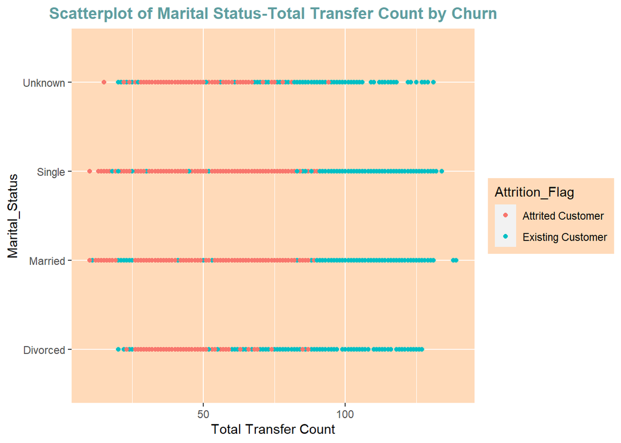

```r
ggplot(data = BankChurners,aes(y=Marital_Status,x=Total_Trans_Ct,col=Attrition_Flag))+geom_point()+labs(title = "Scatterplot of Marital Status-Total Transfer Count by Churn",x="Total Transfer Count",fill="Attrition Flag")+theme(panel.background = element_rect(fill = "peachpuff"))+theme(plot.title = element_text(hjust = 0.5,face = "bold",colour = "cadetblue"))+theme(legend.background = element_rect(fill = "peachpuff"))
```

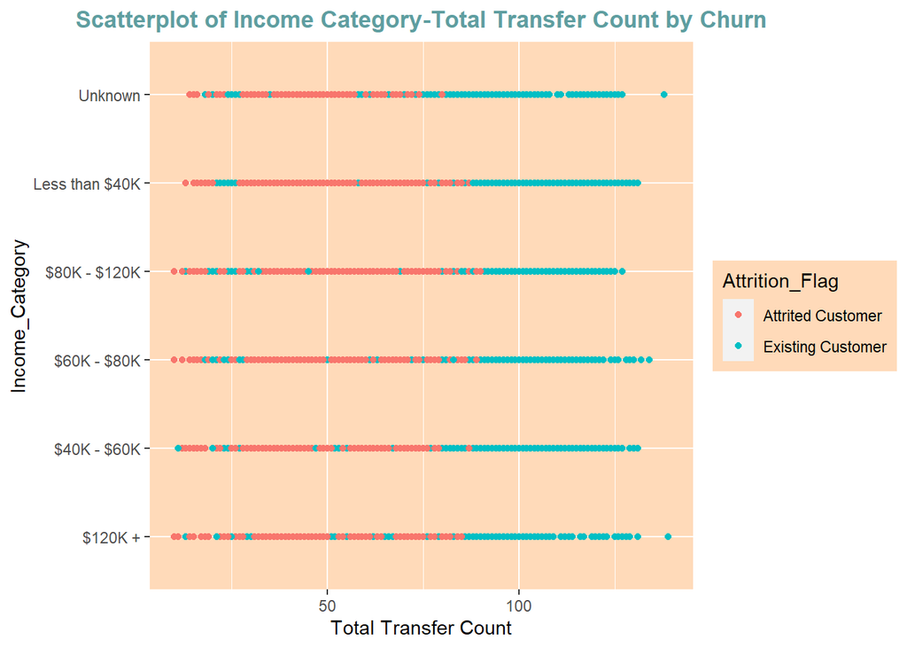

```r
ggplot(data = BankChurners,aes(y=Income_Category,x=Total_Trans_Ct,col=Attrition_Flag))+geom_point()+labs(title = "Scatterplot of Income Category-Total Transfer Count by Churn",x="Total Transfer Count",fill="Attrition Flag")+theme(panel.background = element_rect(fill = "peachpuff"))+theme(plot.title = element_text(hjust = 0.5,face = "bold",colour = "cadetblue"))+theme(legend.background = element_rect(fill = "peachpuff"))
```

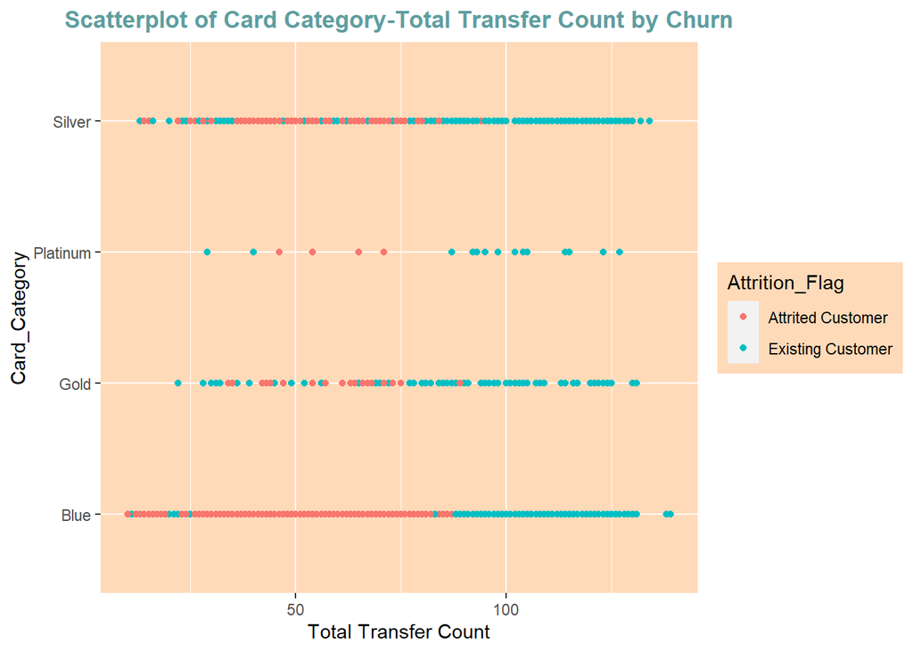

```r
ggplot(data = BankChurners,aes(y=Card_Category,x=Total_Trans_Ct,col=Attrition_Flag))+geom_point()+labs(title = "Scatterplot of Card Category-Total Transfer Count by Churn",x="Total Transfer Count",fill="Attrition Flag")+theme(panel.background = element_rect(fill = "peachpuff"))+theme(plot.title = element_text(hjust = 0.5,face = "bold",colour = "cadetblue"))+theme(legend.background = element_rect(fill = "peachpuff"))
```

1. From the above four graphs we observe that the Bank has high attrition rates of upto 75 Total Transaction Count irrespective of any mentioned category.